# PD 2

# Importy

```python
%matplotlib inline
import pandas as pd
from pandas_profiling import ProfileReport
import numpy as np
import sklearn
from sklearn.impute import KNNImputer
from sklearn.experimental import enable_iterative_imputer
from sklearn.impute import IterativeImputer
from sklearn.preprocessing import StandardScaler
import matplotlib.pyplot as plt
import matplotlib
import warnings
import seaborn as sns
warnings.filterwarnings('ignore')
np.random.seed(23)
import category_encoders as ce
```

# *Część I*

## Treść

Wykonaj target encoding dla zmiennej it_location. Czy i jakie są przewagi target encoding nad one-hot? Jako target traktujemy kolumnę price (będzie to więc zadanie regresji).

Zastosuj trzy metody encodingu (one-hot + "dwie nowe") dla kolumny main_category. "Nowe metody" proszę wybrać spośród wymienionych na stronie https://contrib.scikit-learn.org/category_encoders/. W przypadku, gdy użyta metoda nie działa proszę o stosowną adnotację. Opisz wyniki.

Zwizalizuj wynik oraz wyjaśnij czym się różnią sposoby kodowania (czemu to działa).

```python
transactions_df = pd.read_csv('allegro-api-transactions.csv', index_col='lp')
transactions_df.sample(3)
```

| lp | date | item_id | categories | pay_option_on_delivery | pay_option_transfer | seller | price | it_is_allegro_standard | it_quantity | it_is_brand_zone | it_seller_rating | it_location | main_category |
| --- | --- | --- | --- | --- | --- | --- | --- | --- | --- | --- | --- | --- | --- |
| 303208 | 2016-04-03 18:17:20 | 6068256052 | ['Delikatesy', 'Herbaty', 'Czarne'] | 1 | 0 | ik-mercado-uk | 22.9 | 0 | 19 | 0 | 5295 | Lincoln | Delikatesy |
| 130798 | 2016-04-03 23:18:29 | 5948515466 | ['Dom i Ogród', 'Wyposażenie', 'Oświetlenie', ... | 1 | 0 | toptools_com_pl | 25.0 | 0 | 0 | 0 | 1549 | Białystok | Dom i Ogród |
| 257614 | 2016-04-03 19:53:27 | 6059197530 | ['Odzież, Obuwie, Dodatki', 'Obuwie', 'Męskie'... | 1 | 1 | N1A_PL | 249.0 | 1 | 0 | 0 | 537 | Szczecin | Odzież, Obuwie, Dodatki |

```python
transactions_df.info()
```

```
<class 'pandas.core.frame.DataFrame'>
Int64Index: 420020 entries, 0 to 420019
Data columns (total 13 columns):
 #   Column                  Non-Null Count   Dtype
---  ------                  --------------   -----
 0   date                    420020 non-null  object
 1   item_id                 420020 non-null  int64
 2   categories              420020 non-null  object
 3   pay_option_on_delivery  420020 non-null  int64
 4   pay_option_transfer     420020 non-null  int64
 5   seller                  420020 non-null  object
 6   price                   420020 non-null  float64
 7   it_is_allegro_standard  420020 non-null  int64
 8   it_quantity             420020 non-null  int64
 9   it_is_brand_zone        420020 non-null  int64
 10  it_seller_rating        420020 non-null  int64
 11  it_location             420020 non-null  object
 12  main_category           420020 non-null  object
dtypes: float64(1), int64(7), object(5)
memory usage: 44.9+ MB
```

```python
len(transactions_df.loc[:,'it_location'].unique())
```

```
10056
```

```python
transactions_df.head()
```

| lp | date | item_id | categories | pay_option_on_delivery | pay_option_transfer | seller | price | it_is_allegro_standard | it_quantity | it_is_brand_zone | it_seller_rating | it_location | main_category |
| --- | --- | --- | --- | --- | --- | --- | --- | --- | --- | --- | --- | --- | --- |
| 0 | 2016-04-03 21:21:08 | 4753602474 | ['Komputery', 'Dyski i napędy', 'Nośniki', 'No... | 1 | 1 | radzioch666 | 59.99 | 1 | 997 | 0 | 50177 | Warszawa | Komputery |
| 1 | 2016-04-03 15:35:26 | 4773181874 | ['Odzież, Obuwie, Dodatki', 'Bielizna damska',... | 1 | 1 | InwestycjeNET | 4.90 | 1 | 9288 | 0 | 12428 | Warszawa | Odzież, Obuwie, Dodatki |
| 2 | 2016-04-03 14:14:31 | 4781627074 | ['Dom i Ogród', 'Budownictwo i Akcesoria', 'Śc... | 1 | 1 | otostyl_com | 109.90 | 1 | 895 | 0 | 7389 | Leszno | Dom i Ogród |
| 3 | 2016-04-03 19:55:44 | 4783971474 | ['Książki i Komiksy', 'Poradniki i albumy', 'Z... | 1 | 1 | Matfel1 | 18.50 | 0 | 971 | 0 | 15006 | Wola Krzysztoporska | Książki i Komiksy |
| 4 | 2016-04-03 18:05:54 | 4787908274 | ['Odzież, Obuwie, Dodatki', 'Ślub i wesele', '... | 1 | 1 | PPHU_RICO | 19.90 | 1 | 950 | 0 | 32975 | BIAŁYSTOK | Odzież, Obuwie, Dodatki |

```python
print(transactions_df.isnull().sum())
```

```
date                      0
item_id                   0
categories                0
pay_option_on_delivery    0
pay_option_transfer       0
seller                    0
price                     0
it_is_allegro_standard    0
it_quantity               0
it_is_brand_zone          0
it_seller_rating          0
it_location               0
main_category             0
dtype: int64
```

```python
X=transactions_df.drop('price', axis =1)
y=transactions_df.drop('it_location', axis=1)
```

## Target Encoder

```python
encoder = ce.TargetEncoder(cols=['it_location'])
encoder.fit(X,y['price'])
df_target_encoder=encoder.transform(X,y['price'])
df_target_encoder.head(3)
```

| lp | date | item_id | categories | pay_option_on_delivery | pay_option_transfer | seller | it_is_allegro_standard | it_quantity | it_is_brand_zone | it_seller_rating | it_location | main_category |
| --- | --- | --- | --- | --- | --- | --- | --- | --- | --- | --- | --- | --- |
| 0 | 2016-04-03 21:21:08 | 4753602474 | ['Komputery', 'Dyski i napędy', 'Nośniki', 'No... | 1 | 1 | radzioch666 | 1 | 997 | 0 | 50177 | 85.423398 | Komputery |
| 1 | 2016-04-03 15:35:26 | 4773181874 | ['Odzież, Obuwie, Dodatki', 'Bielizna damska',... | 1 | 1 | InwestycjeNET | 1 | 9288 | 0 | 12428 | 85.423398 | Odzież, Obuwie, Dodatki |
| 2 | 2016-04-03 14:14:31 | 4781627074 | ['Dom i Ogród', 'Budownictwo i Akcesoria', 'Śc... | 1 | 1 | otostyl_com | 1 | 895 | 0 | 7389 | 61.990914 | Dom i Ogród |

```python
len(df_target_encoder.loc[:,'it_location'].unique())
```

```
6283
```

```python
onehot = ce.OneHotEncoder(handle_unknown='ignore')
encoded_onehot = pd.DataFrame(onehot.fit_transform(transactions_df[["main_category"]]))
data_onehot = transactions_df.join(encoded_onehot)
data_onehot.head(3)
```

| lp | date | item_id | categories | pay_option_on_delivery | pay_option_transfer | seller | price | it_is_allegro_standard | it_quantity | it_is_brand_zone | ... | main_category_18 | main_category_19 | main_category_20 | main_category_21 | main_category_22 | main_category_23 | main_category_24 | main_category_25 | main_category_26 | main_category_27 |
| --- | --- | --- | --- | --- | --- | --- | --- | --- | --- | --- | --- | --- | --- | --- | --- | --- | --- | --- | --- | --- | --- |
| 0 | 2016-04-03 21:21:08 | 4753602474 | ['Komputery', 'Dyski i napędy', 'Nośniki', 'No... | 1 | 1 | radzioch666 | 59.99 | 1 | 997 | 0 | ... | 0 | 0 | 0 | 0 | 0 | 0 | 0 | 0 | 0 | 0 |
| 1 | 2016-04-03 15:35:26 | 4773181874 | ['Odzież, Obuwie, Dodatki', 'Bielizna damska',... | 1 | 1 | InwestycjeNET | 4.90 | 1 | 9288 | 0 | ... | 0 | 0 | 0 | 0 | 0 | 0 | 0 | 0 | 0 | 0 |
| 2 | 2016-04-03 14:14:31 | 4781627074 | ['Dom i Ogród', 'Budownictwo i Akcesoria', 'Śc... | 1 | 1 | otostyl_com | 109.90 | 1 | 895 | 0 | ... | 0 | 0 | 0 | 0 | 0 | 0 | 0 | 0 | 0 | 0 |

3 rows × 40 columns

Inspirując się artykułem: https://medium.com/analytics-vidhya/target-encoding-vs-one-hot-encoding-with-simple-examples-276a7e7b3e64, udało mi się wyróżnić proste wady i zalety każdego z kodowań.

**OneHot**

*Zalety:*

Działa dobrze w przypadku danych nominalnych i eliminuje problem z wyższymi wartościami kategorycznymi wpływającymi na dane, ponieważ tworzymy każdą kolumnę w binarnej 1 lub 0.

*Wady:*

Może stworzyć bardzo dużą wymiarowość w zależności od liczby posiadanych cech kategorycznych i liczby kategorii na obiekt, co w ostateczności doprowadzić może do bardzo działania.

**Target**

*Opis:*

Polega na tym, że funkcje są zastępowane połączeniem późniejszego prawdopodobieństwa celu przy danej określonej wartości kategorycznej i wcześniejszego prawdopodobieństwa celu względem wszystkich danych uczących.

*Zalety:*

Prosta i szybka metoda kodowania, która nie zwiększa wymiarowości zbioru danych.

*Wady:*

Zależy ono od dystrybucji celu, co oznacza, że wymaga starannej weryfikacji, ponieważ może być podatne na overfitting. Ta metoda jest również specyficzna dla zbioru danych i będzie wykazywać znaczną poprawę tylko przez pewien czas.

## *OneHotEncoding*

```python
X3=transactions_df.drop('price', axis =1)
y3=transactions_df.drop('main_category', axis =1)
ce_one_hot = ce.OneHotEncoder(cols = ['main_category'])
ce_one_hot_df=ce_one_hot.fit_transform(X3,y3)
```

```python
ce_one_hot_df.iloc[:, 11:38]
```

| lp | main_category_1 | main_category_2 | main_category_3 | main_category_4 | main_category_5 | main_category_6 | main_category_7 | main_category_8 | main_category_9 | main_category_10 | ... | main_category_18 | main_category_19 | main_category_20 | main_category_21 | main_category_22 | main_category_23 | main_category_24 | main_category_25 | main_category_26 | main_category_27 |
| --- | --- | --- | --- | --- | --- | --- | --- | --- | --- | --- | --- | --- | --- | --- | --- | --- | --- | --- | --- | --- | --- |
| 0 | 1 | 0 | 0 | 0 | 0 | 0 | 0 | 0 | 0 | 0 | ... | 0 | 0 | 0 | 0 | 0 | 0 | 0 | 0 | 0 | 0 |
| 1 | 0 | 1 | 0 | 0 | 0 | 0 | 0 | 0 | 0 | 0 | ... | 0 | 0 | 0 | 0 | 0 | 0 | 0 | 0 | 0 | 0 |
| 2 | 0 | 0 | 1 | 0 | 0 | 0 | 0 | 0 | 0 | 0 | ... | 0 | 0 | 0 | 0 | 0 | 0 | 0 | 0 | 0 | 0 |
| 3 | 0 | 0 | 0 | 1 | 0 | 0 | 0 | 0 | 0 | 0 | ... | 0 | 0 | 0 | 0 | 0 | 0 | 0 | 0 | 0 | 0 |
| 4 | 0 | 1 | 0 | 0 | 0 | 0 | 0 | 0 | 0 | 0 | ... | 0 | 0 | 0 | 0 | 0 | 0 | 0 | 0 | 0 | 0 |
| ... | ... | ... | ... | ... | ... | ... | ... | ... | ... | ... | ... | ... | ... | ... | ... | ... | ... | ... | ... | ... | ... |
| 420015 | 0 | 0 | 0 | 0 | 0 | 1 | 0 | 0 | 0 | 0 | ... | 0 | 0 | 0 | 0 | 0 | 0 | 0 | 0 | 0 | 0 |
| 420016 | 0 | 0 | 0 | 0 | 0 | 0 | 0 | 0 | 1 | 0 | ... | 0 | 0 | 0 | 0 | 0 | 0 | 0 | 0 | 0 | 0 |
| 420017 | 0 | 1 | 0 | 0 | 0 | 0 | 0 | 0 | 0 | 0 | ... | 0 | 0 | 0 | 0 | 0 | 0 | 0 | 0 | 0 | 0 |
| 420018 | 0 | 0 | 0 | 0 | 0 | 0 | 0 | 1 | 0 | 0 | ... | 0 | 0 | 0 | 0 | 0 | 0 | 0 | 0 | 0 | 0 |
| 420019 | 0 | 0 | 0 | 0 | 0 | 0 | 1 | 0 | 0 | 0 | ... | 0 | 0 | 0 | 0 | 0 | 0 | 0 | 0 | 0 | 0 |

420020 rows × 27 columns

```python
OneHot=ce_one_hot_df.iloc[:, 11:38]
OneHot=OneHot.sum()
OneHot
```

```
main_category_1     14491
main_category_2     54257
main_category_3     91042
main_category_4     11572
main_category_5      5808
main_category_6     20341
main_category_7     45941
main_category_8     42107
main_category_9     28096
main_category_10    19805
main_category_11    27532
main_category_12     8074
main_category_13     6146
main_category_14     7150
main_category_15     6574
main_category_16    13166
main_category_17     5959
main_category_18     1005
main_category_19     2381
main_category_20     3194
main_category_21      617
main_category_22     1961
main_category_23     1053
main_category_24      413
main_category_25     1214
main_category_26      119
main_category_27        2
dtype: int64
```

```
<BarContainer object of 27 artists>
```

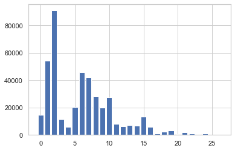

```python
bars = ('main_category_1', 'main_category_2','main_category_3', 'main_category_4','main_category_5', 'main_category_6','main_category_7', 'main_category_8','main_category_9', 'main_category_10','main_category_11', 'main_category_12','main_category_13', 'main_category_14','main_category_15', 'main_category_16','main_category_17', 'main_category_18','main_category_19', 'main_category_20','main_category_21', 'main_category_22','main_category_23', 'main_category_24','main_category_25','main_category_26','main_category_27')
y_pos = np.arange(len(bars))
plt.bar(y_pos,OneHot)
```

Metoda OneHotEncoding działa w ten sposób, że rozdziela zadaną kolumnę na wszystkie unikalne kategorie (kolejne kolumny zamiast tamtej) i następnie dla każdej zmiennej daje 1 w miejscu gdzie chodzi o daną kategorię, a 0 jeśli nie.

## *LeaveOneOut*

```python
X4=transactions_df.drop('price', axis =1)
y4=transactions_df.drop('main_category', axis =1)
ce_leave = ce.LeaveOneOutEncoder(cols = ['main_category'])
ce_leave.fit(X4, y4['price'])
ce_leave_df=ce_leave.transform(X4, y4['price'])
```

```python
leave=ce_leave_df.iloc[:, 11:38]
leave
```

| lp | main_category |
| --- | --- |
| 0 | 121.814331 |
| 1 | 75.859357 |
| 2 | 72.434342 |
| 3 | 25.028061 |
| 4 | 75.859080 |
| ... | ... |
| 420015 | 107.530709 |
| 420016 | 28.129044 |
| 420017 | 75.859337 |
| 420018 | 71.203327 |
| 420019 | 134.418844 |

420020 rows × 1 columns

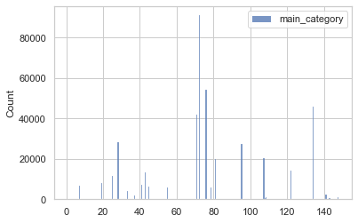

```python
sns.histplot(leave)
```

Kodowanie Leave One Out oblicza średnią zmiennych docelowych dla wszystkich rekordów zawierających tę samą wartość dla danej zmiennej jakościowej. Algorytm kodowania różni się nieco w zestawie danych uczących i testowych.

W przypadku danych walidacyjnych lub zestawu danych prognozowania definicja jest nieco inna. Nie musimy zostawiać aktualnego rekordu i nie potrzebujemy czynnika losowości.

## *Helmert Encoding*

```python
X5=transactions_df.drop('price', axis =1)
y5=transactions_df.drop('main_category', axis =1)
ce_helmert = ce.HelmertEncoder(cols = ['main_category'])
ce_helmert_df=ce_helmert .fit_transform(X5, y5)
```

```python
helmert=ce_helmert_df.iloc[:, 13:39]
helmert
```

| lp | main_category_1 | main_category_2 | main_category_3 | main_category_4 | main_category_5 | main_category_6 | main_category_7 | main_category_8 | main_category_9 | main_category_10 | ... | main_category_16 | main_category_17 | main_category_18 | main_category_19 | main_category_20 | main_category_21 | main_category_22 | main_category_23 | main_category_24 | main_category_25 |
| --- | --- | --- | --- | --- | --- | --- | --- | --- | --- | --- | --- | --- | --- | --- | --- | --- | --- | --- | --- | --- | --- |
| 0 | -1.0 | -1.0 | -1.0 | -1.0 | -1.0 | -1.0 | -1.0 | -1.0 | -1.0 | -1.0 | ... | -1.0 | -1.0 | -1.0 | -1.0 | -1.0 | -1.0 | -1.0 | -1.0 | -1.0 | -1.0 |
| 1 | -1.0 | -1.0 | -1.0 | -1.0 | -1.0 | -1.0 | -1.0 | -1.0 | -1.0 | -1.0 | ... | -1.0 | -1.0 | -1.0 | -1.0 | -1.0 | -1.0 | -1.0 | -1.0 | -1.0 | -1.0 |
| 2 | 2.0 | -1.0 | -1.0 | -1.0 | -1.0 | -1.0 | -1.0 | -1.0 | -1.0 | -1.0 | ... | -1.0 | -1.0 | -1.0 | -1.0 | -1.0 | -1.0 | -1.0 | -1.0 | -1.0 | -1.0 |
| 3 | 0.0 | 3.0 | -1.0 | -1.0 | -1.0 | -1.0 | -1.0 | -1.0 | -1.0 | -1.0 | ... | -1.0 | -1.0 | -1.0 | -1.0 | -1.0 | -1.0 | -1.0 | -1.0 | -1.0 | -1.0 |
| 4 | -1.0 | -1.0 | -1.0 | -1.0 | -1.0 | -1.0 | -1.0 | -1.0 | -1.0 | -1.0 | ... | -1.0 | -1.0 | -1.0 | -1.0 | -1.0 | -1.0 | -1.0 | -1.0 | -1.0 | -1.0 |
| ... | ... | ... | ... | ... | ... | ... | ... | ... | ... | ... | ... | ... | ... | ... | ... | ... | ... | ... | ... | ... | ... |
| 420015 | 0.0 | 0.0 | 0.0 | 5.0 | -1.0 | -1.0 | -1.0 | -1.0 | -1.0 | -1.0 | ... | -1.0 | -1.0 | -1.0 | -1.0 | -1.0 | -1.0 | -1.0 | -1.0 | -1.0 | -1.0 |
| 420016 | 0.0 | 0.0 | 0.0 | 0.0 | 0.0 | 0.0 | 8.0 | -1.0 | -1.0 | -1.0 | ... | -1.0 | -1.0 | -1.0 | -1.0 | -1.0 | -1.0 | -1.0 | -1.0 | -1.0 | -1.0 |
| 420017 | -1.0 | -1.0 | -1.0 | -1.0 | -1.0 | -1.0 | -1.0 | -1.0 | -1.0 | -1.0 | ... | -1.0 | -1.0 | -1.0 | -1.0 | -1.0 | -1.0 | -1.0 | -1.0 | -1.0 | -1.0 |
| 420018 | 0.0 | 0.0 | 0.0 | 0.0 | 0.0 | 7.0 | -1.0 | -1.0 | -1.0 | -1.0 | ... | -1.0 | -1.0 | -1.0 | -1.0 | -1.0 | -1.0 | -1.0 | -1.0 | -1.0 | -1.0 |
| 420019 | 0.0 | 0.0 | 0.0 | 0.0 | 6.0 | -1.0 | -1.0 | -1.0 | -1.0 | -1.0 | ... | -1.0 | -1.0 | -1.0 | -1.0 | -1.0 | -1.0 | -1.0 | -1.0 | -1.0 | -1.0 |

420020 rows × 25 columns

```python
helmert.max(axis=1)
```

```
lp
0        -1.0
1        -1.0
2         2.0
3         3.0
4        -1.0
         ...
420015    5.0
420016    8.0
420017   -1.0
420018    7.0
420019    6.0
Length: 420020, dtype: float64
```

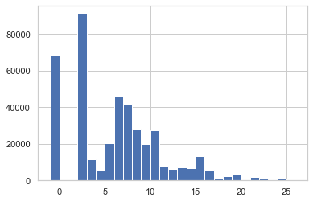

```python
n_bins=27
plt.hist(helmert.max(axis=1), bins=n_bins)
plt.show()
```

Kodowanie Helmerta jest typem kodowania kategorialnego dla regresji. Porównuje każdy poziom zmiennej kategorialnej ze średnią kolejnych poziomów. Stąd pierwszy kontrast porównuje średnią zmiennej zależnej ze średnią wszystkich kolejnych poziomów kolumny kategorialnej, drugi kontrast porównuje średnią zmienna zależna ze średnią wszystkich kolejnych poziomów, itd.

# *Część II*

## Treść

W tej części zadania traktujemy zmienną price nie jak target a zmienną objaśniającą. Zbiór danych ograniczamy do zmiennych numerycznych tj. price, it_seller_rating i it_quantity.

Proszę losowo usunąć 10% wartości ze zmiennej it_seller_rating i je uzupełnić z użyciem jednego z automatycznych narzędzi: Nearest neighbors imputation lub Multivariate feature imputation (https://scikit-learn.org/stable/modules/impute.html). Następnie należy porównać wartości imputowane z oryginalnymi (polecam miarę RMSE). Eksperyment powtórzyć 10 razy i zobaczyć jakie będzie odchylenie standardowe wyniku. Następnie zrobić analogiczną analizę gdy oprócz losowego usuwania 10% wartości z kolumny it_seller_rating usuniemy także losowo 10% ze zmiennej it_quantity. (w przypadku problemów wydajnościowych proszę ograniczyć liczbę rekordów).

Opisać wnioski z analizy jakości imputacji i umieścić podsumowujący wykres.

## **Pojedyncza iteracja**

Najpierw dokonajmy pojedynczej iteracji dla opisanego zadania z usuwaniem danych tylko z jednej kolumny.

```python
df=transactions_df[['price', 'it_seller_rating', 'it_quantity']]
df2=df.copy()
df2
```

| lp | price | it_seller_rating | it_quantity |
| --- | --- | --- | --- |
| 0 | 59.99 | 50177 | 997 |
| 1 | 4.90 | 12428 | 9288 |
| 2 | 109.90 | 7389 | 895 |
| 3 | 18.50 | 15006 | 971 |
| 4 | 19.90 | 32975 | 950 |
| ... | ... | ... | ... |
| 420015 | 180.00 | 176 | 0 |
| 420016 | 14.99 | 34851 | 2 |
| 420017 | 5.99 | 983 | 470 |
| 420018 | 200.00 | 163 | 0 |
| 420019 | 500.00 | 265 | 0 |

420020 rows × 3 columns

```python
df2.loc[df.sample(frac=0.1).index, 'it_seller_rating'] = np.nan
df2
```

| lp | price | it_seller_rating | it_quantity |
| --- | --- | --- | --- |
| 0 | 59.99 | NaN | 997 |
| 1 | 4.90 | NaN | 9288 |
| 2 | 109.90 | 7389.0 | 895 |
| 3 | 18.50 | 15006.0 | 971 |
| 4 | 19.90 | 32975.0 | 950 |
| ... | ... | ... | ... |
| 420015 | 180.00 | 176.0 | 0 |
| 420016 | 14.99 | 34851.0 | 2 |
| 420017 | 5.99 | 983.0 | 470 |
| 420018 | 200.00 | 163.0 | 0 |
| 420019 | 500.00 | 265.0 | 0 |

420020 rows × 3 columns

```python
df2.isnull().sum()
```

```
price                   0
it_seller_rating    42002
it_quantity             0
dtype: int64
```

Do imputacji brakujących zmiennych używam IterativeImputera (Multivariate feature imputation)

```python
imp = IterativeImputer(random_state=0, skip_complete=True, n_nearest_features=10)
df3=imp.fit_transform(df2)
df3=pd.DataFrame(df3, columns=['price','it_seller_rating','it_quantity'])
df3
```

|  | price | it_seller_rating | it_quantity |
| --- | --- | --- | --- |
| 0 | 59.99 | 19999.720065 | 997.0 |
| 1 | 4.90 | 20657.103009 | 9288.0 |
| 2 | 109.90 | 7389.000000 | 895.0 |
| 3 | 18.50 | 15006.000000 | 971.0 |
| 4 | 19.90 | 32975.000000 | 950.0 |
| ... | ... | ... | ... |
| 420015 | 180.00 | 176.000000 | 0.0 |
| 420016 | 14.99 | 34851.000000 | 2.0 |
| 420017 | 5.99 | 983.000000 | 470.0 |
| 420018 | 200.00 | 163.000000 | 0.0 |
| 420019 | 500.00 | 265.000000 | 0.0 |

420020 rows × 3 columns

```python
df3.isnull().sum()
```

```
price               0
it_seller_rating    0
it_quantity         0
dtype: int64
```

Imputer zadziałał, gdyż nie mamy brakujących danych.

```python
sklearn.metrics.mean_squared_error(df.iloc[:, 1],df3.iloc[:, 1],squared=False)
```

```
11507.569618984044
```

```python
np.std(df, ddof=0)
```

```
price                 390.325807
it_seller_rating    36682.854968
it_quantity         23387.220223
dtype: float64
```

```python
np.std(df3, ddof=0)
```

```
price                 390.325807
it_seller_rating    34832.035651
it_quantity         23387.220223
dtype: float64
```

## 10 iteracji dla jednej kategorii wybrakowanych

```python
imp = IterativeImputer(max_iter=10000, random_state=10, n_nearest_features=100,initial_strategy='mean')
v1 = []
for i in range(10):
    df2=df.copy()
    df2.loc[df.sample(frac=0.1).index, 'it_seller_rating'] = np.nan
    df3=imp.fit_transform(df2)
    df3=pd.DataFrame(df3, columns=['price','it_seller_rating','it_quantity'])
    v1.append(sklearn.metrics.mean_squared_error(df.iloc[:, 1],df3.iloc[:, 1], squared=False))
    print("Mean squared Error : " + str(sklearn.metrics.mean_squared_error(df.iloc[:, 1],df3.iloc[:, 1], squared=False)))
    print('Standard deviation for all variables:')
    print(np.std(df3, ddof=0))
    print(" ")
std1 = np.std(v1, axis=0)
print('Standard deviation for RMSE: '+str(std1))
```

```
Mean squared Error : 11474.430138044092
Standard deviation for all variables:
price                 390.325807
it_seller_rating    34842.773131
it_quantity         23387.220223
dtype: float64

Mean squared Error : 11707.60109155759
Standard deviation for all variables:
price                 390.325807
it_seller_rating    34766.164589
it_quantity         23387.220223
dtype: float64

Mean squared Error : 11488.739522367108
Standard deviation for all variables:
price                 390.325807
it_seller_rating    34835.598269
it_quantity         23387.220223
dtype: float64

Mean squared Error : 11844.305952651463
Standard deviation for all variables:
price                 390.325807
it_seller_rating    34718.130580
it_quantity         23387.220223
dtype: float64

Mean squared Error : 11707.40672959509
Standard deviation for all variables:
price                 390.325807
it_seller_rating    34765.656698
it_quantity         23387.220223
dtype: float64

Mean squared Error : 11689.285776808923
Standard deviation for all variables:
price                 390.325807
it_seller_rating    34770.961417
it_quantity         23387.220223
```

[output cut: 16 more lines]

```
Mean squared Error : 11515.108678136365
Standard deviation for all variables:
price                 390.325807
it_seller_rating    34828.080240
it_quantity         23387.220223
dtype: float64

Mean squared Error : 11746.855261997292
Standard deviation for all variables:
price                 390.325807
it_seller_rating    34751.287331
it_quantity         23387.220223
dtype: float64

Standard deviation for RMSE: 140.87517398414397
```

## 10 iteracji dla dwóch kategorii wybrakowanych

```python
imp = IterativeImputer(max_iter=10000, random_state=10, n_nearest_features=100,initial_strategy='mean')
v2 = []
v3 = []
for i in range(10):
    df2=df.copy()
    df2.loc[df.sample(frac=0.1).index, 'it_seller_rating'] = np.nan
    df2.loc[df.sample(frac=0.1).index, 'it_quantity'] = np.nan
    df3=imp.fit_transform(df2)
    df3=pd.DataFrame(df3, columns=['price','it_seller_rating','it_quantity'])
    v2.append(sklearn.metrics.mean_squared_error(df.iloc[:, 1],df3.iloc[:, 1], squared=False))
    v3.append(sklearn.metrics.mean_squared_error(df.iloc[:, 2],df3.iloc[:, 2], squared=False))
    print("Mean squared Error it_seller_rating: " + str(sklearn.metrics.mean_squared_error(df.iloc[:, 1],df3.iloc[:, 1], squared=False)))
    print("Mean squared Error it_quantity: " + str(sklearn.metrics.mean_squared_error(df.iloc[:, 2],df3.iloc[:, 2], squared=False)))
    print('Standard deviation for all variables:')
    print(np.std(df3, ddof=0))
    print(" ")
std2 = np.std(v2, axis=0)
print('Standard deviation for it_seller_rating RMSE: '+str(std2))
std3 = np.std(v3, axis=0)
print('Standard deviation for it_quantity RMSE: '+str(std3))
```

```
Mean squared Error it_seller_rating: 11581.166380281838
Mean squared Error it_quantity: 7376.380193145194
Standard deviation for all variables:
price                 390.325807
it_seller_rating    34807.348699
it_quantity         22199.738230
dtype: float64

Mean squared Error it_seller_rating: 11736.051699440259
Mean squared Error it_quantity: 7286.696792394862
Standard deviation for all variables:
price                 390.325807
it_seller_rating    34755.733495
it_quantity         22221.560022
dtype: float64

Mean squared Error it_seller_rating: 11446.976324595043
Mean squared Error it_quantity: 7232.664449095855
Standard deviation for all variables:
price                 390.325807
it_seller_rating    34851.801346
it_quantity         22241.186198
dtype: float64

Mean squared Error it_seller_rating: 11630.095610833767
Mean squared Error it_quantity: 7394.396087233159
Standard deviation for all variables:
price                 390.325807
it_seller_rating    34791.162040
it_quantity         22186.449861
dtype: float64

Mean squared Error it_seller_rating: 11488.109957166322
Mean squared Error it_quantity: 7462.060026761094
Standard deviation for all variables:
price                 390.325807
it_seller_rating    34838.049612
it_quantity         22170.328697
dtype: float64

```

[output cut: 27 more lines]

```
price                 390.325807
it_seller_rating    34836.782480
it_quantity         22172.055119
dtype: float64

Mean squared Error it_seller_rating: 11699.966312477713
Mean squared Error it_quantity: 7479.6175811038875
Standard deviation for all variables:
price                 390.325807
it_seller_rating    34768.576449
it_quantity         22160.133969
dtype: float64

Standard deviation for it_seller_rating RMSE: 121.52931356311746
Standard deviation for it_quantity RMSE: 77.38877481689728
```

## Wnioski po imputacji:

W obu przypadkach imputacja jest wysoce nieskuteczna, gdyż błąd średniokwadratowy jest duży.

Widoczne są też zmiany w wariancjach zmiennych które były uzupełniane.

Z drugiej strony stron, w przypadku braków danych, jest to coś z czego faktycznie opłaca się korzystać, gdyż jesteśmy w stanie pozyskać jedynie w małym,stopniu zaburzone rekordy, za to w dużej ilości.

```python
itera=[1,2,3,4,5,6,7,8,9,10]
iters=[0,1,2,3,4,5,6,7,8,9]
```

## Wizualizacje RMSE

[figure not shown]

```python
sns.set(style="whitegrid", color_codes=True)
fig, ax = plt.subplots()
sns.barplot(itera, y=v1, color='blue', saturation=0.5)
ax.set_ylim(11000,12000)
plt.title('RMSE for first test')
plt.show()
```

[figure not shown]

```python
sns.set(style="whitegrid", color_codes=True)
fig, ax = plt.subplots()
sns.barplot(itera, y=v2, color='cyan')
ax.set_ylim(11000,12000)
plt.title('RMSE for second test, middle column')
plt.show()
```

[figure not shown]

```python
sns.set(style="whitegrid", color_codes=True)
fig, ax = plt.subplots()
sns.barplot(itera, y=v3, color='darkblue')
ax.set_ylim(7000,7600)
plt.title('RMSE for second test, last column')
plt.show()
```